# Exploring SAUP LME 54 data

**Looking at the Far East portion**

```r
rus_FE_sec = rus_FE%>%
              group_by(Sector,Year,TaxonName,CommonName)%>%
                summarize(catch=sum(CatchAmount))

unique(rus_FE_sec$Sector)
```

```
## [1] Artisanal    Industrial   Recreational Subsistence
## Levels: Artisanal Industrial Recreational Subsistence
```

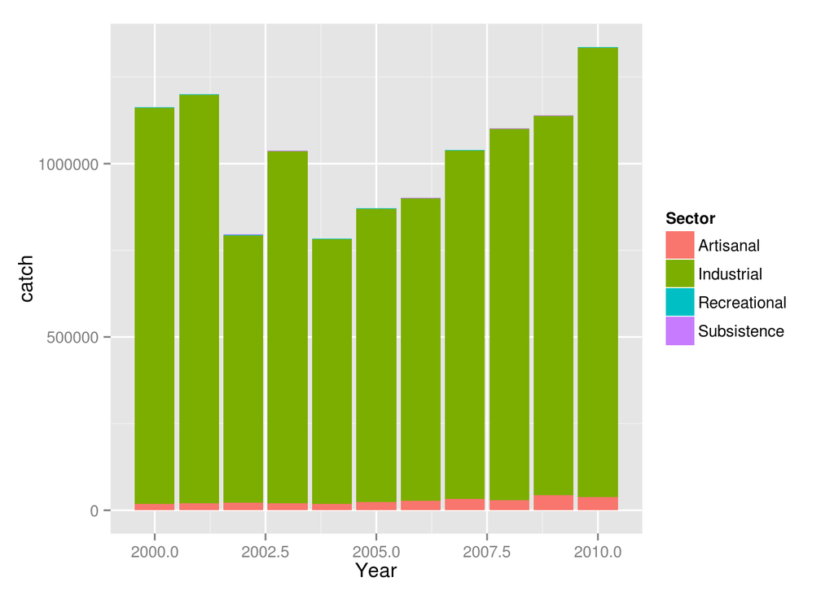

```r
sec = ggplot(rus_FE_sec,aes(Year,catch,fill=Sector))+geom_bar(stat='identity')
print(sec)
```

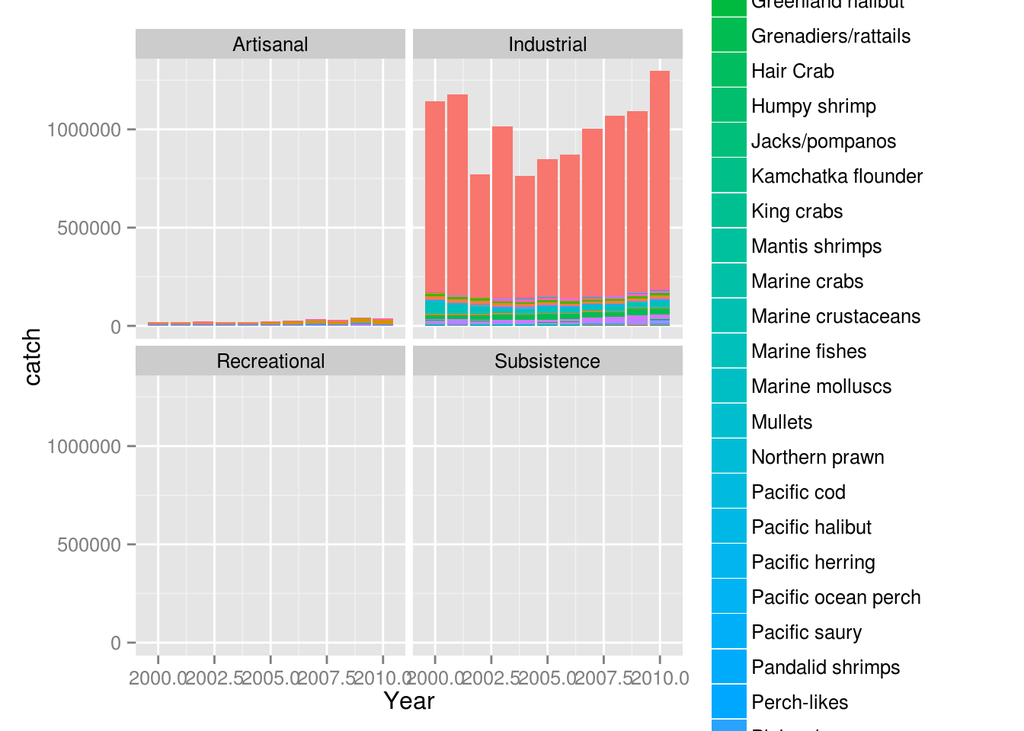

```r
sec = ggplot(rus_FE_sec,aes(Year,catch,fill=CommonName))+geom_bar(stat='identity')+facet_wrap(~Sector)
print(sec)
```

```r
s = rus_FE%>%
        group_by(Sector)%>%
         summarize(catch=sum(CatchAmount))
s
```

```
## Source: local data frame [4 x 2]
##
##         Sector        catch
## 1    Artisanal   297251.573
## 2   Industrial 11054764.814
## 3 Recreational    10932.227
## 4  Subsistence     8719.617
```

Focusing on industrial catch and compare it to the total catch we are using now…

```r
comm = rus_FE%>%
        filter(Sector=='Industrial')

comm_yr_catch = comm%>% group_by(Year)%>%
            summarize(catch=sum(CatchAmount))

length(unique(comm$TaxonName)) #67 species caught
```

```
## [1] 67
```

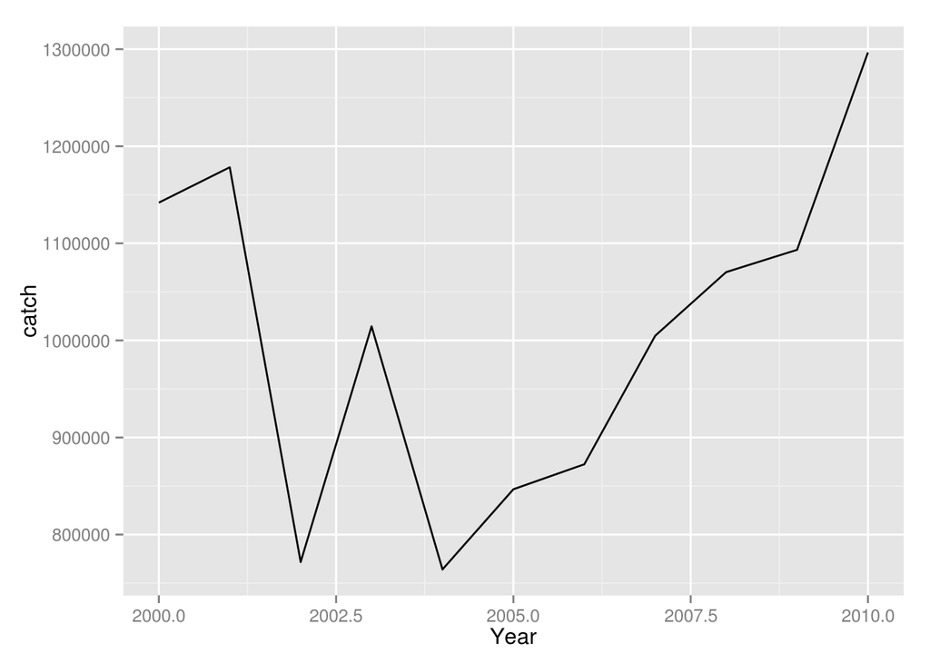

```r
catch_time = ggplot(comm_yr_catch,aes(Year,catch))+geom_line(stat='identity')
print(catch_time)
```

```r
unique(comm$CommonName)
```

```
##  [1] Marine fishes            Shrimps and prawns
##  [3] Marine crustaceans       Marine molluscs
##  [5] Sea urchins              Sharks and rays
##  [7] Clams                    True jellyfishes
##  [9] Skates and rays          Cods
## [11] Flatfishes               Squids
## [13] Cuttlefishes             Salmonids
## [15] Smelts                   Codlings
## [17] Grenadiers/rattails      Jacks/pompanos
## [19] Porgies                  Mullets
## [21] Gobies                   Righteye flounders
## [23] Sea mussels              Alfonsinos
## [25] Eelpouts                 Salmons/trouts
## [27] Common squids            Cupped oysters
## [29] Tanner/snow crabs        Pandalid shrimps
```

[output cut: 19 more lines]

TOP 20 SPECIES CAUGHT BY TONS

```r
top20 = comm%>%
          group_by(CommonName)%>%
            summarize(catch=sum(CatchAmount))%>%
            top_n(20)

top20
```

```
## Source: local data frame [20 x 2]
##
##               CommonName      catch
## 1         Alaska pollock 9309858.99
## 2          Atka mackerel  143043.37
## 3                Capelin   67226.94
## 4             Flatfishes  101807.64
## 5                 Gobies   27548.96
## 6    Grenadiers/rattails  292268.90
## 7         Jacks/pompanos   22664.96
## 8         Mantis shrimps   18420.82
## 9     Marine crustaceans   19177.09
## 10         Marine fishes  312164.91
## 11       Marine molluscs   46811.76
## 12       Pacific herring   35309.61
## 13           Pink salmon   71854.76
## 14           Saffron cod  149459.02
## 15 Same-spine stone crab  137791.05
## 16    Shrimps and prawns   63475.72
## 17        Sockeye salmon   30443.70
## 18                Squids   59525.17
## 19     Tanner/snow crabs   34930.14
## 20      True jellyfishes   24438.73
```

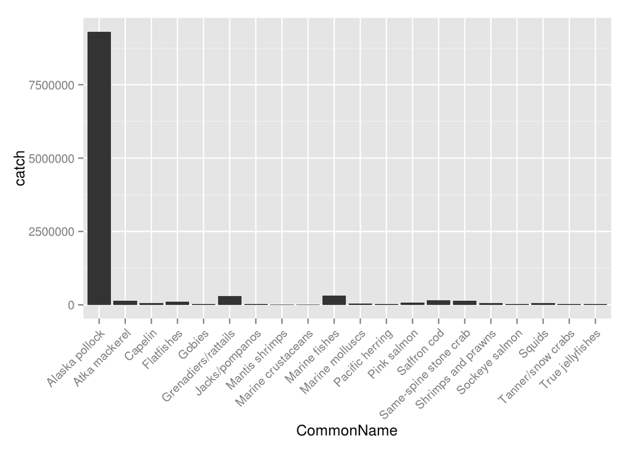

```r
top20_plot = ggplot(top20,aes(CommonName,catch))+geom_bar(stat='identity')+
  theme(axis.text.x=element_text(angle=45,hjust=1,vjust=1))
print(top20_plot)
```

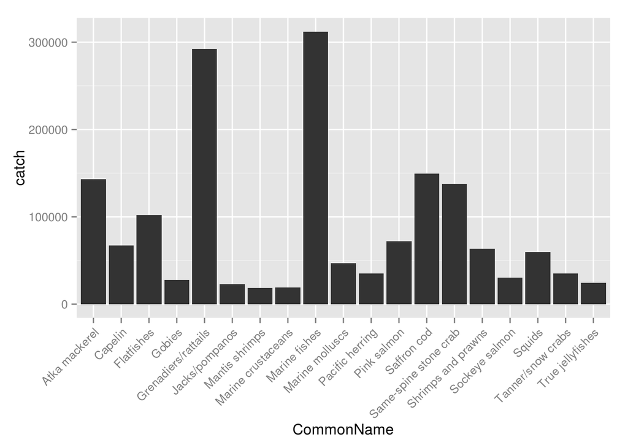

```r
#Remove pollock

noPollock = top20%>%filter(catch<max(top20$catch))

noP = ggplot(noPollock,aes(CommonName,catch))+geom_bar(stat='identity')+
  theme(axis.text.x=element_text(angle=45,hjust=1,vjust=1))
print(noP)
```

Since I don’t know how these species are caught, we can do waht we did for OHI 2015. We can calculate the proportion of catch each cell has for each gear type. Then apply that proportion to the total tonnage for the region.